# After the Storm

Carbon, Timber, and the Science of What Happens When 822,000 Acres Fall

Author

Ryan Lafferty

Published

April 28, 2026

## The Scale of What Fell

Hurricane Helene made landfall on September 26, 2024 as a Category 4 storm. Its path through the Southern Appalachians was not the story that was expected. The mountains absorbed rainfall measured in feet, not inches, over 48 hours. Landslides erased roads. Rivers carved new channels through towns. And across an estimated 822,000 acres of Western North Carolina timberland, trees fell.

The number is hard to hold. 822,000 acres is larger than Rhode Island. Before the storm, that forest held roughly **83 million metric tons of carbon**, stored in wood, roots, and leaf litter accumulated over decades of growth. When trees fall and decompose without intervention, most of that carbon returns to the atmosphere as CO2 within years to decades. The storm was a carbon event as much as a flood event. The two stories have not often been told together.

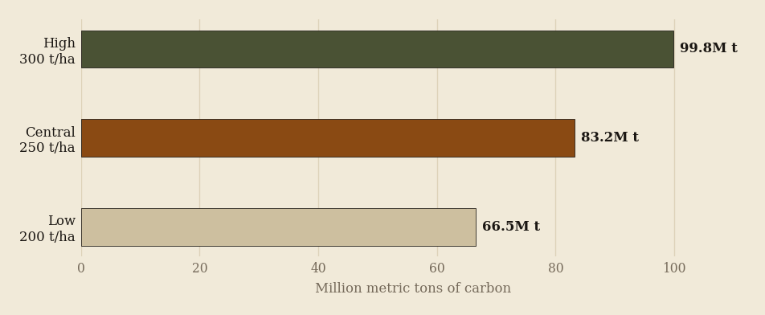

Carbon stored in the Hurricane Helene impact zone under low, mid, and high forest density estimates. Central estimate (250 metric tons per hectare) used throughout this report. Source: USDA Forest Carbon FAQs; impact area from USDA Forest Service post-storm assessment.

## The Geographic Context

The storm’s path cut diagonally across the Blue Ridge escarpment, where the Appalachian plateau drops into the Piedmont. The rivers that drained this terrain, the Swannanoa, the French Broad, the Pigeon, had nowhere to send 30 inches of rain in 48 hours. The resulting floods carried debris from the mountains through the valleys, stripping streambanks and depositing sediment in channels not seen flood-stage since before settlement.

The highest density of treefall followed the ridge lines, where saturated soils released shallow-rooted trees across vast stretches of second- and third-growth forest. Much of this timber was economically mature or approaching it.

Western North Carolina and the Southern Appalachian impact zone of Hurricane Helene (September 2024). Green circles show high-impact counties. Amber dashed line: approximate storm track. Basemap: CartoDB Voyager.

[interactive chart not shown]

## What the Wood Holds

A standing tree is a carbon account that has been accumulating deposits for decades. The carbon is not evenly distributed. Roughly 47 percent of dry wood mass is carbon. When a tree dies and decomposes in aerobic conditions, that carbon cycles back into the atmosphere through fungal and bacterial decomposition, at rates that depend on temperature, moisture, and wood density. In a warm, wet climate like Western North Carolina, a large fallen hardwood may be fully incorporated back into the soil carbon cycle within 20 to 30 years.

That timeline matters. The carbon stored in 822,000 acres of timberland, taken at the central estimate of 250 metric tons per hectare, amounts to approximately 83 million metric tons. For context, that is roughly equivalent to 18 million passenger cars driven for one year. If that wood decomposes without intervention, the majority of that carbon enters the atmosphere over the next two to three decades.

The question the Helene event poses is whether some portion of that release can be prevented, and at what scale.

## The Four Techniques

Four approaches to sequestering carbon from fallen timber have documented scientific basis. They differ in durability, cost, scale, and the form the carbon takes after intervention.

### Burial: Woody Biomass Burial (WBB)

The simplest approach is also among the most durable. Burying woody biomass in anaerobic conditions, where the absence of oxygen dramatically slows decomposition, can preserve 50 to 80 percent of the stored carbon over a century or more. The IPCC recognized wood buried in solid waste disposal sites as a form of carbon sequestration in 2019, noting the potential to retain over 99.9 percent of carbon over a 100-year period under optimal conditions.

The method requires no chemical transformation. Fallen trees are placed in sealed pits or subsurface vaults, covered with clay or impermeable material, and left. The challenge is scale and cost. Moving and burying the volume of timber produced by a storm like Helene requires heavy machinery, suitable sites, and ongoing monitoring. Researchers at Yale and elsewhere have proposed commercial “wood vaults” as a scalable negative emissions technology.

### Biochar: Controlled Pyrolysis

Heating biomass in a low-oxygen environment through pyrolysis produces biochar, a stable carbon-rich solid that resists decomposition in soil for hundreds to thousands of years. The process can capture 45 to 75 percent of the biomass carbon in a stable form, with the remainder released as syngas (some of which can offset fossil fuel use).

The additional benefit is agronomic. Biochar applied to agricultural soils improves water retention, cation exchange capacity, and microbial activity. In a region where small-scale farming and forest agriculture are economically significant, a biochar program from storm debris could serve dual purposes.

The constraint is throughput. A commercial pyrolysis unit processes tens to hundreds of tons per day. The Helene impact zone produced millions of tons of biomass. Industrial-scale deployment would require significant capital and infrastructure investment.

### Cross-Laminated Timber (CLT)

Fallen timber that is commercially viable can be processed into cross-laminated timber, an engineered wood product used in construction. CLT locks the stored carbon in place for the lifespan of the structure, typically 50 to 100 years, and substitutes for concrete and steel whose production is energy-intensive. The sequestration rate, 55 to 65 percent of original carbon, reflects the carbon cost of processing and transport offset against long-term storage in built form.

The limitation here is wood quality. Storm-damaged timber often shows compression failures, sapwood exposure, and rapid blue-stain fungal colonization that can degrade structural value. The window for salvage processing is narrow, typically 6 to 18 months before decay accelerates. Western North Carolina had active salvage timber operations underway by winter 2024, but regional mill capacity was itself damaged by the storm.

### Bioplastics: Wood to PLA

At the most technically ambitious end, fallen timber can be broken down through chemical and biological processes into lactic acid, which polymerizes into polylactic acid (PLA), a compostable bioplastic. The cellulose and lignin in wood are hydrolyzed to fermentable sugars, which bacteria then convert to lactic acid at scale. This sequesters carbon in a material form that can replace petroleum-derived plastics, with a sequestration efficiency of 30 to 55 percent.

The technology exists at pilot scale. Industrial deployment from disaster timber is not yet demonstrated. The process is expensive relative to petroleum plastics at current fossil fuel prices, but the carbon math changes substantially under any serious carbon pricing regime.

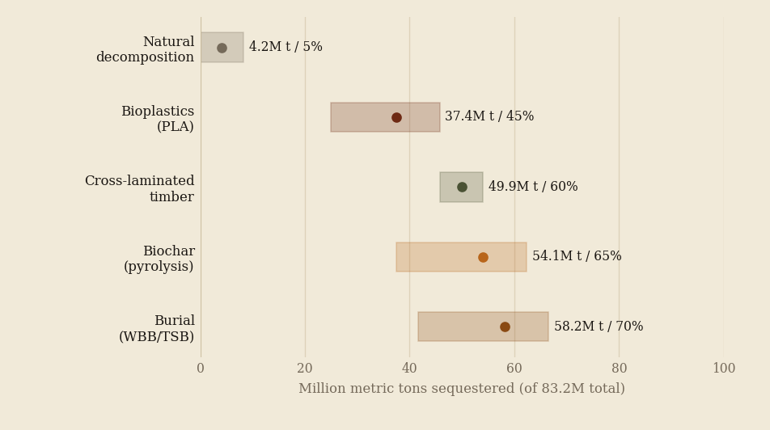

Carbon sequestration rates by technique applied to the Helene impact zone (central estimate: 83.2M metric tons total). Low, mid, and high efficiency ranges per peer-reviewed literature. Natural decomposition baseline shown for reference. Sources: IPCC (2019), Yale Carbon Containment Lab, Nature Reviews Earth & Environment (2023).

## The GEE Remote Sensing Approach

Calculating carbon at the landscape scale requires remote sensing. The Helene impact zone spans eight counties and several distinct forest types, including mixed Appalachian hardwoods, Fraser fir, red spruce, and commercial pine plantation. Ground-based inventory alone cannot map the impact at the resolution and speed required for management decisions.

Three Google Earth Engine datasets are directly applicable:

**GEDI (Global Ecosystem Dynamics Investigation)** provides 3D measurements of forest structure from a LiDAR instrument aboard the International Space Station. The `rh100` band captures canopy height at the 100th percentile, which correlates strongly with aboveground biomass. Pre-storm GEDI data for the region provides a baseline against which post-storm change can be measured.

**ALOS PALSAR** provides L-band synthetic aperture radar biomass estimates. SAR penetrates cloud cover and tree canopy, making it particularly useful in the post-storm period when optical imagery is often unavailable or shows incomplete storm coverage.

**Sentinel-1 SAR** enables change detection between pre- and post-storm acquisitions. SAR backscatter from standing forest is distinctly different from that of fallen timber, allowing automated detection of treefall at 10-meter resolution.

The workflow below can be run at code.earthengine.google.com. It requires defining a `geometry` variable for the eight-county impact zone as a starting point.

```javascript
// 1. Pre-storm NDVI baseline from Landsat 8
var landsat8 = ee.ImageCollection('LANDSAT/LC08/C02/T1_L2')
  .filterBounds(geometry)
  .filterDate('2024-06-01', '2024-09-25');  // pre-storm window

var ndvi = landsat8.map(function(image) {
  return image.normalizedDifference(['SR_B5', 'SR_B4']).rename('NDVI');
}).mean();

// 2. GEDI canopy height — pre-storm structure baseline
var gedi       = ee.ImageCollection('LARSE/GEDI/GEDI02_B_002');
var gediHeight = gedi.select('rh100');  // 100th percentile canopy height
Map.addLayer(gediHeight, {
  min: 0, max: 50,
  palette: ['#0c1a0e', '#166534', '#22c55e', '#86efac']
}, 'GEDI Canopy Height');

// 3. ALOS PALSAR aboveground biomass estimate
var palsarBiomass = ee.Image('JAXA/ALOS/PALSAR/YEARLY/SAR/2017');
var carbonStorage = palsarBiomass.clip(geometry)
  .reduceRegion({
    reducer:  ee.Reducer.sum(),
    geometry: geometry,
    scale:    30
  })
  .get('Biomass')
  .multiply(0.5);  // biomass to carbon: ~0.5 conversion factor
print('Total Carbon Storage (metric tons):', carbonStorage);

// 4. Post-storm treefall detection via Sentinel-1 SAR change
var s1Pre  = ee.ImageCollection('COPERNICUS/S1_GRD')
  .filterBounds(geometry)
  .filterDate('2024-08-01', '2024-09-26')
  .mean();

var s1Post = ee.ImageCollection('COPERNICUS/S1_GRD')
  .filterBounds(geometry)
  .filterDate('2024-10-01', '2024-11-30')
  .mean();

var change = s1Post.subtract(s1Pre);  // negative values = canopy loss
Map.addLayer(change, {
  min: -10, max: 10,
  palette: ['#ef4444', '#374151', '#22c55e']
}, 'SAR Change Detection');
```

## What the Numbers Mean

The scale of Helene’s carbon impact sits in a range with real policy relevance. If the 83 million metric tons in the impact zone were to decompose naturally over 25 years, the annual emission would be approximately 3.3 million metric tons of CO2-equivalent per year, comparable to the annual emissions of a medium-sized coal plant, sustained for two and a half decades.

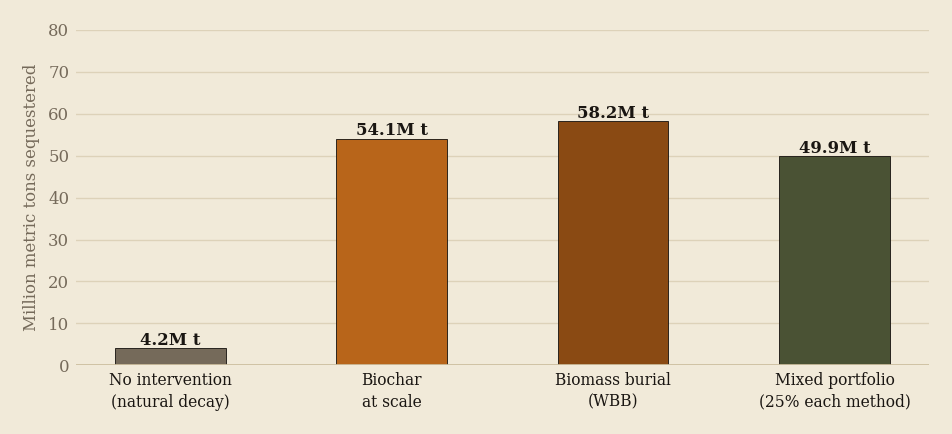

Carbon fate scenarios for the Helene impact zone under different management approaches. Values represent metric tons sequestered under central efficiency estimates. The ‘business as usual’ natural decomposition scenario sequesters roughly 4M metric tons (soil carbon fraction) while releasing the remainder.

The mixed portfolio scenario is the most operationally realistic. It assumes that different forest types, ownership structures, and site conditions will favor different techniques. Commercial timber salvage flows to CLT mills. Slash and logging debris that cannot be milled goes to biochar production. Areas with suitable geology and land ownership receive biomass burial. The result, under central estimates, is roughly 50 million metric tons sequestered instead of released.

That is not a solution to climate change. It is a management decision about whether a catastrophe becomes a source or a managed sink.

## Sequestration Technique Summary

| Technique | Sequestration Rate | Durability | Key Constraint | Status |
| --- | --- | --- | --- | --- |
| Burial (WBB/TSB) | 50-80% | Centuries | Land + logistics | IPCC-recognized (2019) |
| Biochar | 45-75% | Centuries | Processing capacity | Commercial scale |
| Cross-laminated Timber | 55-65% | Building lifespan | Salvage window (6-18 mo) | Proven commercial |
| Bioplastics (PLA) | 30-55% | Product lifespan | Technology cost | Pilot scale |
| Natural decomposition | ~5% | N/A | Baseline only | Business as usual |

## Data and Methods

**Impact area:** 822,000 acres reported by USDA Forest Service post-storm assessment of Hurricane Helene (October 2024).

**Carbon density:** 200-300 metric tons per hectare range drawn from USDA Forest Carbon FAQs and peer-reviewed literature for mixed Appalachian hardwood forest. Central estimate: 250 metric tons per hectare.

**Sequestration rates:** Burial rates from Yale Carbon Containment Lab and IPCC Sixth Assessment Report Working Group III. Biochar rates from *Nature Reviews Earth and Environment* (2023) review of pyrolysis carbon permanence. CLT rates from *Journal of Cleaner Production* lifecycle analyses. Bioplastics rates from pilot-scale PLA production studies.

**GEE datasets:** LANDSAT/LC08/C02/T1_L2, LARSE/GEDI/GEDI02_B_002, JAXA/ALOS/PALSAR/YEARLY/SAR, COPERNICUS/S1_GRD.

**Note:** This analysis uses regional forest carbon averages. A site-specific assessment using GEDI and ALOS PALSAR would refine the biomass estimates considerably. The calculations are intended to establish order-of-magnitude context for policy planning, not precise carbon accounting.

[← geoglypha1.org](https://www.geoglypha1.org/)